# 중간고사

__________학과 학번__________ 이름__________

2016-10-17

#### 1. Data for US Top Income Shares

다음 물음에 답하시오.

##### 1.1

다음 문서에서 ’E. Saez 교수의 홈페이지’는 URL이다. 적절한 코드를 고르시오.

가. `(E. Saez 교수의 홈페이지)(http://elsa.berkeley.edu/~saez/)`

나. `(E. Saez 교수의 홈페이지)[http://elsa.berkeley.edu/~saez/]`

다. `[E. Saez 교수의 홈페이지](http://elsa.berkeley.edu/~saez/)`

라. `[E. Saez 교수의 홈페이지][http://elsa.berkeley.edu/~saez/]`

> 준비한 자료는 [E. Saez 교수의 홈페이지](http://elsa.berkeley.edu/~saez/)에 있는 [`TabFig2015prel.xls`](http://eml.berkeley.edu//~saez/TabFig2015prel.xls)` 를 손봐서 불러들인 것이다.

```r
options(digits = 3)
library(xlsx)
US.top.income.shares.15 <- read.xlsx("../data/TabFig2015prel.xlsx", sheetIndex = 9, sheetName = "Table A3", startRow = 6, endRow = 108, colIndex = c(1:7, 9:13), colClasses = c("integer", rep("numeric", 12)), header = FALSE)
v.names <- c("Year", "P90_100", "P95_100", "P99_100", "P99.5_100", "P99.9_100", "P99.99_100", "P90_95", "P95_99", "P99_99.5", "P99.5_99.9", "P99.9_99.99")
names(US.top.income.shares.15) <- v.names
str(US.top.income.shares.15)
ls()
save.image(file = "US_top_income_shares_2015.RData")
```

##### 1.2

위의 코드 묶음에서 `library(xlsx)`가 작동하기 위해서는 다음 중 어떤 코드가 먼저 수행되었어야 하는가?

가. `install.packages("xlsx")`

나. `installed.packages("xlsx")`

다. `update.packages("xlsx")`

라. `download.packages("xlsx")`

##### 1.3

위의 코드로부터 읽어들이고자 하는 엑셀 자료는 몇 줄짜리인가?

가. 101줄

나. 102줄

다. 103줄

라. 104줄

##### 1.4

다음 중 반드시 필요한 설정은 무엇인가?

가. `sheetIndex = 9`

나. `endRow = 108`

다. `colIndex = c(1:7, 9:13)`

라. `header = FALSE`

##### 1.5

`names(US.top.income.shares.15) <- v.names`를 주석처리하면, 각 변수들의 이름은 어떻게 될 것인가?

가. `X1, X2, ..., X13`

나. `V1, V2, ..., V13`

다. `A1, A2, ..., A13`

라. `A, B, ..., M`

##### 1.6

`ls()`의 결과로 옳게 나온 것은?

가. `## [1] "US.top.income.shares.15"`

나. `## [1] "v.names"`

다. `## [1] "US.top.income.shares.15", "v.names"`

라. `## [1] "v.names", "US.top.income.shares.15"`

##### 1.7

`save.image(file = "US_top_income_shares_2015.RData")`의 결과물을 읽어들이려면 필요한 코드는?

가. `getwd("US_top_income_shares_2015.RData")`

나. `read.table("US_top_income_shares_2015.RData")`

다. `load("US_top_income_shares_2015.RData")`

라. `attach("US_top_income_shares_2015.RData")`

#### 2. Plots for US Top Income Shares

다음 plot과 이를 그리는 데 사용된 코드 묶음을 보고 물음에 답하시오.

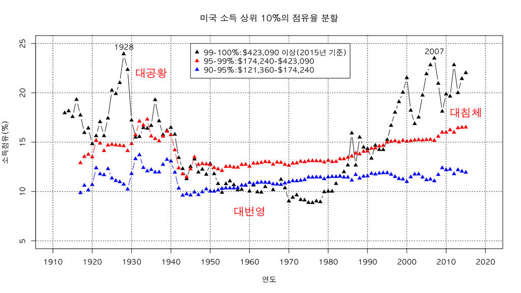

```r
par(family = "AppleGothic")
plot(P99_100 ~ Year, data = US.top.income.shares.15, xlab = "연도", ylab = "소득점유(%)", xlim = c(1910, 2020), ylim = c(5, 25), xaxt = "n", type = "b", pch = 17)
axis(side = 1, at = seq(1910, 2020, by = 10), labels = seq(1910, 2020, by = 10))
lines(P95_99 ~ Year, data = US.top.income.shares.15, type = "b", pch = 17, col = "red")
lines(P90_95 ~ Year, data = US.top.income.shares.15, type = "b", pch = 17, col = "blue")
abline(h = seq(5, 25, by = 5), lty = 3)
abline(v = seq(1910, 2020, by = 10), lty = 3)
legend.text <- c("99-100%:$423,090 이상(2015년 기준)", "95-99%:$174,240-$423,090", "90-95%:$121,360-$174,240")
legend(x = 1945, y = 25, legend = legend.text, pch = 17, col = c("black", "red", "blue"))
main.title <- "미국 소득 상위 10%의 점유율 분할"
title(main = main.title)
y.1928 <- US.top.income.shares.15$P99_100[US.top.income.shares.15$Year == 1928]
y.2007 <- US.top.income.shares.15$P99_100[US.top.income.shares.15$Year == 2007]
text(x = c(1928, 2007), y = c(y.1928, y.2007), labels = c(1928, 2007), pos = 3)
times.label <- c("대공황", "대번영", "대침체")
text(x = c(1935, 1960, 2015), y = c(22, 8, 18), label = times.label, cex = 1.5, col = "red")
```

##### 2.1

다음 코드를 수행하였을 때 나오는 x-축의 라벨과 y-축의 라벨을 제대로 짝지은 것은?

```
plot(P99_100 ~ Year, data = US.top.income.shares.15)
```

가. `Year`, `P99_100`

나. `P99_100`, `Year`

다. `US.top.income.shares.15$Year`, `US.top.income.shares.15$P99_100`

라. `US.top.income.shares.15$P99_100`, `US.top.income.shares.15$Year`

##### 2.2

위의 코드 묶음에서 점과 선을 동시에 표현하는 데 사용된 코드는 무엇인가?

가. `xlim = c(1910, 2020)`

나. `ylim = c(5, 25)`

다. `type = "b"`

라. `pch = 17`

##### 2.3

위의 코드 묶음에서 y축의 범위를 정하는 데 사용된 코드는 무엇인가?

가. `xlim = c(1910, 2020)`

나. `ylim = c(5, 25)`

다. `type = "b"`

라. `pch = 17`

##### 2.4

위의 코드 묶음에서 격자 점선의 종류를 정하는 데 사용된 코드는 무엇인가?

가. `h = seq(5, 25, by = 5)`

나. `v = seq(1910, 2020, by = 10)`

다. `lty = 3`

라. `pch = 17`

##### 2.5

범례의 위치를 정하는 데 사용된 좌표는 범례 박스의 어느 부분인가?

가. 왼쪽 위

나. 오른쪽 위

다. 왼쪽 아래

라. 오른쪽 아래

##### 2.6

메인 타이틀의 크기를 현재보다 두배로 하려면 어떤 코드를 추가하여야 하는가?

가. `cex = 2.0`

나. `cex.main = 2.0`

다. `main.cex = 2.0`

라. `main = 2.0`

##### 2.7

1928년도의 상위 1%의 소득점유율(%)을 출력하는 코드는 다음 중 무엇인가?

가. `y.1928 <- US.top.income.shares.15$P99_100[US.top.income.shares.15$Year == 1928]`

나. `y.2007 <- US.top.income.shares.15$P99_100[US.top.income.shares.15$Year == 2007]`

다. `US.top.income.shares.15$P99_100[US.top.income.shares.15$Year == 1928]`

라. `US.top.income.shares.15$P99_100[US.top.income.shares.15$Year == 2007]`

##### 2.8

`1928`과 `2007`의 위치를 정하는 데 사용된 코드는 무엇인가?

가. `x = c(1928, 2007)`

나. `y = c(y.1928, y.2007)`,

다. `labels = c(1928, 2007)`

라. `pos = 3`

##### 2.9

`대번영`의 좌표는 다음 중 어느 것인가?

가. `x = 1935, y = 22`

나. `x = 1960, y = 8`

다. `x = 2015, y = 18`

라. `x = 1960, y = 18`

##### 2.10

윈도우용 R을 사용한다면 굳이 설정하지 않아도 되는 코드는 다음 중 어느 것인가?

가. `par(family = "AppleGothic")`

나. `axis(side = 1, at = seq(1910, 2020, by = 10), labels = seq(1910, 2020, by = 10))`

다. `abline(h = seq(5, 25, by = 5), lty = 3)`

라. `title(main = main.title)`

#### 3. 팀 나누기

##### 3.1

아래 코드묶음으로부터 `names(class_roll)[4]`의 결과는 어떻게 나오겠는가?

```r
class_roll <- read.xlsx("../data/class_roll.xlsx", 1, startRow = 2, endRow = 23, colIndex = c(3:7, 9), colClasses = rep("character", 6), stringsAsFactors = FALSE)
str(class_roll)
names(class_roll) <- c("dept", "id", "name", "year", "e.mail", "cell.no")
str(class_roll)
names(class_roll)[4]
kable(class_roll)
```

가. `## [1] "dept"`

나. `## [1] "id"`

다. `## [1] "name"`

라. `## [1] "year"`

##### 3.2

위의 코드 묶음에서 `kable(class_roll)`의 결과가 제대로 나오려면 어떤 코드가 먼저 나왔어야 하는가?

가. `install.packages("knitr")`

나. `library(knitr)`

다. `update.packages("knitr")`

라. `remove.packages("knitr")`

##### 3.3

다음 코드에서 각 일련변호를 랜덤하게 늘어놓은 후 5로 나눈 나머지를 구하는 코드는 무엇인가?

```r
set.seed(3)
N <- nrow(class_roll)
group <- 1 + sample(1:N) %% 5
class_roll$group <- factor(group, levels = 1:5, labels = paste("Team", 1:5))
```

가. `set.seed(3)`

나. `N <- nrow(class_roll)`

다. `sample(1:N) %% 5`

라. `group <- 1 + sample(1:N) %% 5`

##### 3.4

다음 코드묶음에서 학번 첫 네자리를 추출하는 코드는 무엇인가?

```r
ID.14 <- factor(ifelse(substr(class_roll$id, 1, 4) >= 2014, "younger.14", "older.14"), levels=c("younger.14", "older.14"), labels = c("14학번 이후", "13학번 이전"))
```

가. `class_roll$id`

나. `substr(class_roll$id, 1, 4)`

다. `ifelse(substr(class_roll$id, 1, 4) >= 2014, "younger.14", "older.14")`

라. `factor(ifelse(substr(class_roll$id, 1, 4) >= 2014, "younger.14", "older.14"))`

##### 3.5

다음 코드묶음에서 e-mail 주소의 사용자이름과 서비스 업체 도메인 명의 리스트에서 도메인명들만을 추출하는 코드는 무엇인가?

```r
e.mail.list <- strsplit(class_roll$e.mail, "@", fixed = TRUE)
mail.com <- mapply("[", e.mail.list, 2)
```

가. `class_roll$e.mail`

나. `strsplit(class_roll$e.mail, "@", fixed = TRUE)`

다. `mapply("[", e.mail.list, 2)`

라. `mail.com <- mapply("[", e.mail.list, 2)`

#### 4 Wilkinson Data

##### 4.1

다음 코드묶음에서 `stringsAsFactors = FALSE`를 `stringsAsFactors = TRUE`로 바꾸면 당초 `character` class이었던 나라명이 무슨 class로 바뀌는가?

```r
data.full <- read.csv("../data/international-inequality_GDP.csv", stringsAsFactors = FALSE)
# data.full <- read.csv("../data/international-inequality_GDP.csv", stringsAsFactors = TRUE)
```

가. `numeric`

나. `factor`

다. `data.frame`

라. `list`

##### 4.2

다음 코드묶음에서 각 코드의 수행결과를 제대로 짝지은 것은?

```r
# is.na(data.full$Index.of.health...social_problems)
# (country.na <- is.na(data.full$Index.of.health...social_problems))
(country.na <- which(is.na(data.full$Index.of.health...social_problems)))
data.full$Country[country.na]
```

가. `is.na(data.full$Index.of.health...social_problems)` : `numeric`

나. `(country.na <- is.na(data.full$Index.of.health...social_problems))` : `logical`

다. `(country.na <- which(is.na(data.full$Index.of.health...social_problems)))` : `logical`

라. `data.full$Country[country.na]` : `factor`

##### 4.3

다음 코드묶음에서 `data.full[-c(11, 18), v.names]`의 수행결과를 제대로 설명한 것은?

```r
v.names <- c("Country", "Income.inequality", "Index.of.health...social_problems", "GDP_WB")
names(data.full) %in% v.names
(v.names.index <- which(names(data.full) %in% v.names))
data.21 <- data.full[-c(11, 18), v.names]
# data.21 <- data.full[-c(11, 18), v.names.index]
```

가. `data.full`의 11번 및 18번쨰 행과 `v.names`에 이름이 나오는 열을 추출한다.

나. `data.full`의 11번 및 18번쨰 행을 제외한 나머지 행과 `v.names`에 이름이 나오는 열을 추출한다.

다. `data.full`의 11번 및 18번쨰 행과 `v.names`에 이름이 나오는 열을 제외한 나머지 열을 추출한다.

라. `data.full`의 11번 및 18번쨰 행을 제외한 나머지 행과 `v.names`에 이름이 나오는 열을 제외한 나머지 열을 추출한다.

#### 5. Plots

##### 5.1

다음 barplot과 이를 그리는 데 사용된 코드에서 barplot을 그리는 데 꼭 있어야 하는 코드는 무엇인가?

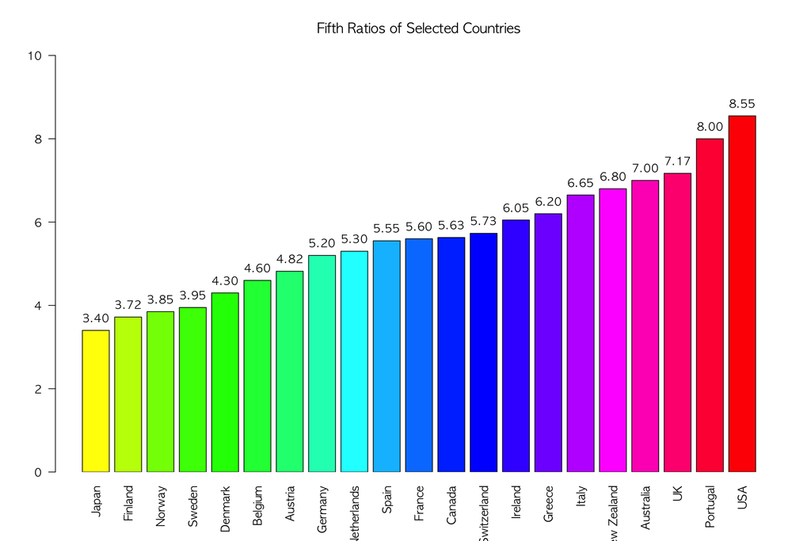

```r
fifth <- data.21$Income.inequality
Country <- data.21$Country
o.fifth <- order(fifth)
N <- nrow(data.21)
b.fifth <- barplot(fifth[o.fifth], names.arg = Country[o.fifth], col = rainbow(N, start = 1/6, end = 1), ylim = c(0, 10), xpd = FALSE, las = 2)
text(x = b.fifth, y = fifth[o.fifth] + 0.3, labels = format(fifth[o.fifth], digits = 3))
title(main = "Fifth Ratios of Selected Countries")
```

가. `fifth[o.fifth]`

나. `names.arg = Country[o.fifth]`

다. `col = rainbow(N, start = 1/6, end = 1)`

라. `ylim = c(0, 10)`

##### 5.2

위의 코드묶음에서 나라 이름을 막대 밑에 나오게 하는 역할을 수행하는 코드는 무엇인가?

가. `fifth[o.fifth]`

나. `names.arg = Country[o.fifth]`

다. `col = rainbow(N, start = 1/6, end = 1)`

라. `ylim = c(0, 10)`

##### 5.3

위의 코드묶음에서 막대의 색깔을 정하는 역할을 수행하는 코드는 무엇인가?

가. `fifth[o.fifth]`

나. `names.arg = Country[o.fifth]`

다. `col = rainbow(N, start = 1/6, end = 1)`

라. `ylim = c(0, 10)`

##### 5.4

위의 코드묶음에서 막대 안쪽으로 소득5분위계수를 써 주려면 `text(...)` 안에서 어떤 코드를 바꿔야 하는가?

가. `x = b.fifth`

나. `y = fifth[o.fifth] + 0.3`

다. `labels = format(fifth[o.fifth], digits = 3)`

라. `digits = 3`

#### Scatter Diagram

##### 5.5

다음 산점도와 이 산점도를 그리는 데 사용된 코드묶음에서 점의 색깔을 정하는 코드는 무엇인가?

가. `pch = 20`

나. `col = "red"`

다. `xlim = c(3, 9), ylim = c(-1.5, 2.5)`

라. `ann = FALSE`

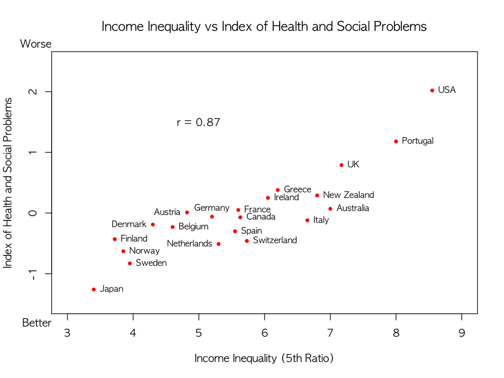

```r
Index_inequality.df <- data.21[c("Income.inequality", "Index.HS")]
cor.1 <- cor(data.21["Income.inequality"], data.21["Index.HS"])
Country <- data.21[, "Country"]
text.left <- which(Country %in% c("Austria", "Denmark", "Germany", "Netherlands"))
text.right <- setdiff(1:nrow(data.21), text.left)
pos.text <- ifelse(1:nrow(data.21) %in% text.left, 2, 4)
text.up <- which(Country %in% "Germany")
text.left <- setdiff(1:nrow(data.21), c(text.right, text.up))
pos.text <- ifelse(1:nrow(data.21) %in% text.up, 3, ifelse(1:nrow(data.21) %in% text.left, 2, 4))
plot(Index_inequality.df, pch = 20, col = "red", xlim = c(3, 9), ylim = c(-1.5, 2.5), ann = FALSE)
text(Index_inequality.df, labels = Country, pos = pos.text, cex = 0.8)
main.title <- "Income Inequality vs Index of Health and Social Problems"
x.lab <- "Income Inequality (5th Ratio)"
y.lab <- "Index of Health and Social Problems"
title(main = main.title, xlab = x.lab, ylab = y.lab)
mtext(c("Better", "Worse"), side = 2, at = c(-1.8, 2.8), las = 1)
text(x = 5, y = 1.5, labels = paste("r =", round(cor.1, digits = 2)))
```

##### 5.6

위의 코드묶음에서 점의 모양을 정하는 코드는 무엇인가?

가. `pch = 20`

나. `col = "red"`

다. `xlim = c(3, 9), ylim = c(-1.5, 2.5)`

라. `ann = FALSE`

##### 5.7

위의 그림에서 `Germany`의 경우 `pos =`이 얼마로 부여되었는가?

가. `1`

나. `2`

다. `3`

라. `4`

##### 5.8

위의 그림에서 상관계수 정보를 소숫점 2자리로 줄인 역할은 어떤 코드가 수행하는가?

가. `x = 5, y = 1.5`

나. `labels = paste("r =",`

다. `round(cor.1, digits = 2))`

라. `digits = 2`